# BAMexploreR: model-based distribution, abundance, and habitat associations of boreal birds **Model Access**

This vignette will show you how to access the BAM landbird density models using the `BAMExploreR` package.

## Background

### Model subregions

The BAM landbird density models are produced by modelling multiple ecologically-distinct regions and mosaicing the model predictions together into a seamless layer.

- **Version 4 regions**: Bird Conservation Regions (BCRs).
- **Version 5 regions**: The intersection of national boundaries and udpated Bird Conservation Regions (BCRs). US boreal models coming soon!

You can choose to access the predictions for the entire modelled area or a custom set of model subregions using an area of interest. For more information on the BAM landbird density models, please see the ‘Introduction’ vignette.

### Subregion naming convention

Due to the intersection of country and BCR as the modelling subregions in version 5 of the BAM landbird models, we use a country prefix and BCR number to name the model subregion. Note that BCR labels differ between version 4 and version 5 due to changes made to several of the BCRs.

```
Version 4 subregion names:  can4 can5 can9 can10 can11 can12 can13 can14 can60 can61 can70 can71 can80 can81 can82 can83
```

```
Version 5 subregion names:  can3 can5 can9 can10 can11 can12 can13 can14 can40 can41 can42 can60 can61 can70 can71 can72 can80 can81 can82
```

## Functions available

### bam_map_bcr()

**bam_map_bcr()** plots the model subregions for a chosen version and can optionally overlay a provided SpatVector to highlight the area of interest.

Arguments

- version: Specifies which version of the landbird density models to use. Valid options are “v4” or “v5”.
- ext: SpatVector or SpatRaster used to define an area of interest.

Output

Map illustrating the BCR and overlap extent if provided.

### bam_get_bcr()

**bam_get_bcr()** returns the list of model subregions for a given model version. If an ext object is supplied, only those subunits that intersect the provided extent are returned.

Arguments

- version: Specifies which version of the landbird density model to use. Valid options are “v4” or “v5”.
- ext: (Optional) SpatVector or SpatRaster whose extent will be used to filter and return only intersecting BCR subunits.

Output

A vector representing the name of the BCR subunits.

### bam_get_layer()

The **bam_get_layer()** function downloads the rasters for the BAM landbird density models for specified the species and area of interest.

Arguments

- spList: A named list of SpatRaster objects, each representing predicted density for a species.
- version: A character specifying which version of the BAM Landbird Density map to use. Valid options are “v4” or “v5”.
- destfile: A character indicating output path where the downloaded file is saved.
- crop_ext: A SpatVector or SpatRaster used to define the extent for the cropping.
- year: A character specifying the year for which the density map were generated. Only in v5. Valid options are “1990”, “1995”, “2000”, “2005”, “2010”, “2015” and “2020”. Default value is “2020”.
- bcrNM: A vector representing the BCR subunit name according to model version. Default is “mosaic”.

Output

A list of multiband SpatRaster objects. In addition to returning these objects, the function also downloads raster files to the directory specified by destfile as a side-effect.

## Example workflow

### 1. Identify species available

The first step in accessing the BAM landbird density model products is determining the species of interest.

There are 143 species available in version 4 of the BAM landbird density models and 66 species available in version 5 (remaining species in progress). You can access the species available for the version of the model specified using the `bam_spp_list` function. The function has a `guild` parameter to filter the available species based on a specific species group, following the classifications used by The State of Canada’s Birds, which categorizes species based on broad biomes and groups with distinct and noteworthy trends. Species listed as ‘Special Concern’, ‘Threatened’, or ‘Endangered’ by the Committee on the Status of Endangered Species in Canada (COSEWIC) is also available. If guild is not provided, the function will return all species available for the specified version of the model.

Let’s check the species group categories by accessing the `guild_opt` object.

```r
# Get the options for species grouping
guild_opt
 [1] "COSEWIC"                "Cavity_Birds"           "Waterfowl"
 [4] "Marine_Birds"           "Shorebirds"             "Wetland_Birds"
 [7] "Birds_of_Prey"          "Forest_Birds"           "Grassland_Birds"
[10] "Aerial_Insectivores"    "Arctic_Birds"           "Long_Distance_Migrants"
```

In our example, we’ll get four-letter AOU codes for ‘COSEWIC’ species available in version 5 of the models.

```r
# Generate a vector of COSEWIC species codes available in version 5.
cosewic_v5 <- bam_spp_list("v5", "speciesCode", "COSEWIC")
cosewic_v5
 [1] "BOBO" "CAWA" "EVGR" "GWWA" "GCTH" "LEYE" "OSFL" "RUBL" "SAVS" "WOTH"
```

We can also retrieve the common names for our COSEWIC species.

```r
# Generate a vector of COSEWIC species common names available in version 5.
cosewic_v5_cn <- bam_spp_list("v5", "commonName", "COSEWIC")
cosewic_v5_cn
 [1] "Bobolink"               "Canada Warbler"         "Evening Grosbeak"
 [4] "Golden-winged Warbler"  "Gray-cheeked Thrush"    "Lesser Yellowlegs"
 [7] "Olive-sided Flycatcher" "Rusty Blackbird"        "Savannah Sparrow"
[10] "Wood Thrush"
```

### 2. Identify model subregions that intersect the area of interest (AOI)

Next, we’ll need to determine the AOI for accessing the model products.

You can choose to access the predictions for the entire modelled area, just a single model subregion (version 5 only), or a custom AOI. Since model subregion names vary by version and country, the `bam_get_bcr` and `bam_map_bcr` functions ensure the correct naming is used. You can specify an extent and identify BCRs intersection the AOI.

For our example, we’ll use an example AOI that intersects two model subregions in the boreal plains and shield. Let’s get the list of model subregions that interest with our AOI.

```r
library(terra)

# Use the example aoi SpatVector provided in the package
aoi_sf <- vect(system.file("extdata", "vignette_poly_5072.shp", package = "BAMexploreR"))

# Extract subregions from version 5 that intersect the aoi
bcraoi_v5 <- bam_get_bcr("v5", ext=aoi_sf)
bcraoi_v5
[1] "can61" "can80"
```

And we can also visualize where our AOI falls on the map of all the model subregions for version 5 using the `bam_map_bcr` function.

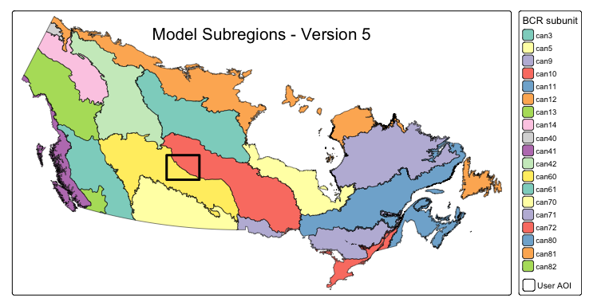

```r
# Map aoi on the map of model subregions
map <- bam_map_bcr("v5", ext=aoi_sf) +
  tmap::tm_title("Model Subregions - Version 5", position = c("center", "top"))
suppressWarnings(print(map))
```

### 3. Download species specific density maps

Now that we have our species and AOI, we can download the model products!

We will download the model products using the `bam_get_layer` function. In version 5, we also have the option of downloading multiple years of predictions, as the density models are available for five-year intervals from 1990 to 2020 (default is 2020).

Let’s download a version 5 `SpatRaster` for our one of our COSEWIC-designated species. We’ll focus on the year 2020, and the two BCRs that our AOI intersects.

```r
#Download the model product for Olive-sided Flycatcher
result <- bam_get_layer(cosewic_v5[7], "v5", destfile = tempdir(), year = "2020", bcrNM=bcraoi_v5)
```

The output of the function is a list of SpatRaster objects. In this example we have a list of one (one species). Note that each of the version 5 model objects has two bands:

- **mean**: the mean predicted density in males/ha across 32 bootstraps
- **cv**: the coefficient of variation of predicted density across 32 bootstraps

The version 4 model products contain only the **mean** band.

Finally, we can plot these bands for our species of interest, Olive-sided Flycatcher.

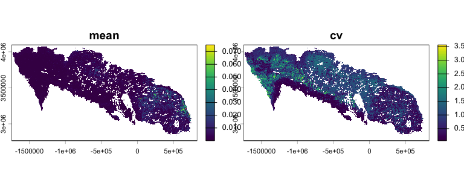

```r
library(terra)

#basic plotting of all bands
plot(result$OSFL)
```